# BMIN503/EPID600 Project Template

### Multiple Predictor Logistic Variables

#PA:LOGISTIC REGRESSION WITH ALL PREDICTORS

> **maternalnativity -1.32182 0.03255 -40.612 < 2e-16** **raceBlack or African American -2.50332 0.02606 -96.064 < 2e-16** raceMore than one race -1.81325 0.06764 -26.806 < 2e-16 *raceAsian -1.24444 0.06344 -19.615 < 2e-16*

```r
#PA: LOGISTIC REGRESSION WITH ALL PREDICTORS
pa.logistic.model <- glm(prenatal ~ age + race + education + maternalnativity, data = clean_PA, family="binomial")
summary (pa.logistic.model)
```

```
##
## Call:
## glm(formula = prenatal ~ age + race + education + maternalnativity,
##     family = "binomial", data = clean_PA)
##
## Deviance Residuals:
##     Min       1Q   Median       3Q      Max
## -3.1345   0.1004   0.1521   0.4122   3.6856
##
## Coefficients:
##                               Estimate Std. Error z value Pr(>|z|)
## (Intercept)                   -1.52874    0.09049 -16.893  < 2e-16 ***
## age15-19                       0.21690    0.04944   4.387 1.15e-05 ***
## age20-24                      -0.40525    0.02951 -13.731  < 2e-16 ***
## age30-34                      -0.11486    0.03090  -3.717 0.000202 ***
## age35-39                       0.09149    0.04253   2.151 0.031451 *
## age40-44                      -0.83462    0.08709  -9.584  < 2e-16 ***
## raceAsian                     -1.24444    0.06344 -19.615  < 2e-16 ***
## raceBlack or African American -2.50332    0.02606 -96.064  < 2e-16 ***
## raceMore than one race        -1.81325    0.06764 -26.806  < 2e-16 ***
## education2                     2.32452    0.08740  26.598  < 2e-16 ***
## education3                     5.05640    0.08468  59.710  < 2e-16 ***
## education4                     6.86884    0.08966  76.614  < 2e-16 ***
## education5                     6.99577    0.09979  70.103  < 2e-16 ***
## education6                     8.07189    0.09810  82.284  < 2e-16 ***
## education7                     8.13849    0.11212  72.589  < 2e-16 ***
## education8                     7.66432    0.14549  52.680  < 2e-16 ***
## maternalnativity              -1.32182    0.03255 -40.612  < 2e-16 ***
## ---
## Signif. codes:  0 '***' 0.001 '**' 0.01 '*' 0.05 '.' 0.1 ' ' 1
##
## (Dispersion parameter for binomial family taken to be 1)
##
##     Null deviance: 108997  on 118530  degrees of freedom
## Residual deviance:  54328  on 118514  degrees of freedom
## AIC: 54362
##
## Number of Fisher Scoring iterations: 7
```

```r
#chi-square for overall model fit (results should be significant)
with(pa.logistic.model, null.deviance - deviance)
```

```
## [1] 54668.45
```

```r
with(pa.logistic.model,df.null-df.residual)
```

```
## [1] 16
```

```r
with(pa.logistic.model,pchisq(null.deviance-deviance,df.null-df.residual, lower.tail = FALSE))
```

```
## [1] 0
```

```r
#convert coefficients to OR instead of log-odds
exp(coef(pa.logistic.model))
```

```
##                   (Intercept)                      age15-19
##                  2.168086e-01                  1.242221e+00
##                      age20-24                      age30-34
##                  6.668115e-01                  8.914911e-01
##                      age35-39                      age40-44
##                  1.095808e+00                  4.340381e-01
##                     raceAsian raceBlack or African American
##                  2.881010e-01                  8.181309e-02
##        raceMore than one race                    education2
##                  1.631237e-01                  1.022180e+01
##                    education3                    education4
##                  1.570242e+02                  9.618276e+02
##                    education5                    education6
##                  1.092009e+03                  3.203165e+03
##                    education7                    education8
##                  3.423738e+03                  2.130944e+03
##              maternalnativity
##                  2.666502e-01
```

```r
#calculate predicted probabilities
pa.newdata <- with(clean_PA, data.frame(maternalnativity=factor(1:2)), education=mean(education))

pa.glm.pred <- predict(pa.logistic.model, clean_PA, type="response")
```

#PHILLY:LOGISTIC REGRESSION WITH ALL PREDICTORS

> **maternalnativity -4.15529 0.10438 -39.809 < 2e-16** *raceMore than one race -4.26353 0.20123 -21.188 < 2e-16* **raceBlack or African American -1.87289 0.07164 -26.142 < 2e-16** *education2 -4.25916 0.30235 -14.087 < 2e-16* **education3 -1.42584 0.21497 -6.633 3.30e-11** *

```r
#PHILLY:LOGISTIC REGRESSION WITH ALL PREDICTORS
philly.logistic.model<- glm(prenatal ~ age + race + education + maternalnativity, data = clean_philly, family="binomial")
summary (philly.logistic.model)
```

```
##
## Call:
## glm(formula = prenatal ~ age + race + education + maternalnativity,
##     family = "binomial", data = clean_philly)
##
## Deviance Residuals:
##     Min       1Q   Median       3Q      Max
## -3.2705  -0.2489   0.0235   0.1701   3.7646
##
## Coefficients:
##                                Estimate Std. Error z value Pr(>|z|)
## (Intercept)                     5.59263    0.27950  20.009  < 2e-16 ***
## age15-19                       -2.15374    0.24253  -8.880  < 2e-16 ***
## age20-24                       -1.59769    0.09043 -17.667  < 2e-16 ***
## age30-34                       -0.20782    0.07739  -2.685  0.00724 **
## age35-39                        1.63799    0.10310  15.888  < 2e-16 ***
## age40-44                        1.26881    0.17977   7.058 1.69e-12 ***
## raceAsian                       1.07854    0.13356   8.075 6.73e-16 ***
## raceBlack or African American  -1.87289    0.07164 -26.142  < 2e-16 ***
## raceMore than one race         -4.26353    0.20123 -21.188  < 2e-16 ***
## education2                     -4.25916    0.30235 -14.087  < 2e-16 ***
## education3                     -1.42584    0.21497  -6.633 3.30e-11 ***
## education4                      3.03515    0.21209  14.310  < 2e-16 ***
## education5                      3.67446    0.23288  15.778  < 2e-16 ***
## education6                      4.87167    0.22527  21.626  < 2e-16 ***
## education7                      5.49055    0.30165  18.202  < 2e-16 ***
## education8                     18.82358  189.63681   0.099  0.92093
## maternalnativity               -4.15529    0.10438 -39.809  < 2e-16 ***
## ---
## Signif. codes:  0 '***' 0.001 '**' 0.01 '*' 0.05 '.' 0.1 ' ' 1
##
## (Dispersion parameter for binomial family taken to be 1)
##
##     Null deviance: 24718.0  on 18083  degrees of freedom
## Residual deviance:  7375.5  on 18067  degrees of freedom
## AIC: 7409.5
##
## Number of Fisher Scoring iterations: 17
```

```r
#chi-square for overall model fit
with(philly.logistic.model, null.deviance - deviance)
```

```
## [1] 17342.5
```

```r
with(philly.logistic.model,df.null-df.residual)
```

```
## [1] 16
```

```r
with(philly.logistic.model,pchisq(null.deviance-deviance,df.null-df.residual, lower.tail = FALSE))
```

```
## [1] 0
```

```r
#convert coefficients to OR instead of log-odds
exp(coef(philly.logistic.model))
```

```
##                   (Intercept)                      age15-19
##                  2.684404e+02                  1.160493e-01
##                      age20-24                      age30-34
##                  2.023631e-01                  8.123548e-01
##                      age35-39                      age40-44
##                  5.144843e+00                  3.556619e+00
##                     raceAsian raceBlack or African American
##                  2.940383e+00                  1.536791e-01
##        raceMore than one race                    education2
##                  1.407251e-02                  1.413422e-02
##                    education3                    education4
##                  2.403055e-01                  2.080418e+01
##                    education5                    education6
##                  3.942755e+01                  1.305390e+02
##                    education7                    education8
##                  2.423897e+02                  1.496159e+08
##              maternalnativity
##                  1.568123e-02
```

```r
#calculate predicted probabilities
philly.glm.pred <- predict(philly.logistic.model, clean_philly, type="response")
```

**Comparatives** >In Pennsylvania when **holding the other predictor variables constant the log-odds of migrant birthing persons receiving adequate prenatal care is lower than US-born citizens by a factor of 1.32 p<0.001.**

> In Philadelphia,when **holding the other predictor variables constant the log-odds of migrant birthing persons receiving adequate prenatal care is lower than US-born citizens by a factor of 4.16 p<0.001.**

### Results

Describe your results and include relevant tables, plots, and code/comments used to obtain them. End with a brief conclusion of your findings related to the question you set out to address. You can include references if you’d like, but this is not required.

### Conclusion

> Our results posit that overall many birthing persons in Philadelphia are not receiving quality prenatal care regardless of maternal characteristics. Given that 43% of the general population had recorded instances of attending less than ten visits, it is imperative to urge the implementation of programs that encourage increased utilization of prenatal visits. This exploration found that Black individuals with low education levels had decreased odds of receiving adequate prenatal care, which can be supported by existing literature.8,9 While this paper explored other social indicators; its primary interest was to understand the association of nativity with prenatal care outcomes. Migrant research is very limited within the State of Pennsylvania and, furthermore, in the City of Philadelphia. To our best knowledge, this is the first study to explore the association maternal nativity may have on receiving adequate prenatal care. Results found that a large proportion of birthing persons born outside of the US are not receiving adequate prenatal care, which may likely be attributed to barriers such as English fluency and understanding of US medical practice.7,9

> The results of this study confirm the need to develop strategies for better healthcare service delivery models for prenatal care services, especially for immigrant populations.

### Limitations & Future Steps

> This study was not able to use the intended data set and, therefore, may not be the most accurate depiction of maternal health outcomes in Philadelphia. The findings of this project will ideally be incorporated into a larger strategy proposal for the City of Philadelphia, which aims to propose a series of recommendations that the Department of Public Health can modify for implementation in Philadelphia to improve prenatal services to undocumented residents through insurance status. We are awaiting IRB approval to conduct the same methods for Philadelphia’s live birth dataset, which would be more accurate and up-to-date. The following study will further assess the association among undocumented immigrants through insurance status and utilize a linear regression instead by breaking prenatal care adequacy into four categories for more specified results. Ideally, we would also do a geospatial distribution to determine the placement of delivery models to benefit the intended immigrant populations.

#Descriptive Table

```r
clean_PA %>%
  gtsummary::tbl_summary(by = prenatal) %>%
  gtsummary::add_p()
```

| **Characteristic** | **0**, N = 20,443<sup>1</sup> | **1**, N = 98,088<sup>1</sup> | **p-value**<sup>2</sup> |
| --- | --- | --- | --- |
| maternalnativity |  |  | <0.001 |
| 1 | 16,207 (79%) | 88,810 (91%) |  |
| 2 | 4,236 (21%) | 9,278 (9.5%) |  |
| race |  |  | <0.001 |
| White | 11,246 (55%) | 84,618 (86%) |  |
| Asian | 724 (3.5%) | 3,371 (3.4%) |  |
| Black or African American | 7,974 (39%) | 9,109 (9.3%) |  |
| More than one race | 499 (2.4%) | 990 (1.0%) |  |
| age |  |  | <0.001 |
| 25-29 | 5,542 (27%) | 27,901 (28%) |  |
| 15-19 | 1,718 (8.4%) | 1,852 (1.9%) |  |
| 20-24 | 6,434 (31%) | 12,150 (12%) |  |
| 30-34 | 4,536 (22%) | 36,303 (37%) |  |
| 35-39 | 1,801 (8.8%) | 17,779 (18%) |  |
| 40-44 | 412 (2.0%) | 2,103 (2.1%) |  |
| education |  |  | <0.001 |
| 1 | 3,518 (17%) | 155 (0.2%) |  |
| 2 | 5,807 (28%) | 2,021 (2.1%) |  |
| 3 | 8,573 (42%) | 22,067 (22%) |  |
| 4 | 1,403 (6.9%) | 17,138 (17%) |  |
| 5 | 409 (2.0%) | 9,246 (9.4%) |  |
| 6 | 450 (2.2%) | 28,074 (29%) |  |
| 7 | 203 (1.0%) | 15,527 (16%) |  |
| 8 | 80 (0.4%) | 3,860 (3.9%) |  |

<sup>1</sup> n (%)  
<sup>2</sup> Pearson's Chi-squared test

```r
clean_PA %>%
  gtsummary::tbl_summary(by = maternalnativity) %>%
  gtsummary::add_p()
```

| **Characteristic** | **1**, N = 105,017<sup>1</sup> | **2**, N = 13,514<sup>1</sup> | **p-value**<sup>2</sup> |
| --- | --- | --- | --- |
| prenatal |  |  | <0.001 |
| 0 | 16,207 (15%) | 4,236 (31%) |  |
| 1 | 88,810 (85%) | 9,278 (69%) |  |
| race |  |  | <0.001 |
| White | 88,304 (84%) | 7,560 (56%) |  |
| Asian | 543 (0.5%) | 3,552 (26%) |  |
| Black or African American | 14,681 (14%) | 2,402 (18%) |  |
| More than one race | 1,489 (1.4%) | 0 (0%) |  |
| age |  |  | <0.001 |
| 25-29 | 29,825 (28%) | 3,618 (27%) |  |
| 15-19 | 3,297 (3.1%) | 273 (2.0%) |  |
| 20-24 | 16,710 (16%) | 1,874 (14%) |  |
| 30-34 | 36,029 (34%) | 4,810 (36%) |  |
| 35-39 | 16,917 (16%) | 2,663 (20%) |  |
| 40-44 | 2,239 (2.1%) | 276 (2.0%) |  |
| education |  |  | <0.001 |
| 1 | 3,114 (3.0%) | 559 (4.1%) |  |
| 2 | 6,758 (6.4%) | 1,070 (7.9%) |  |
| 3 | 26,762 (25%) | 3,878 (29%) |  |
| 4 | 16,731 (16%) | 1,810 (13%) |  |
| 5 | 9,038 (8.6%) | 617 (4.6%) |  |
| 6 | 25,234 (24%) | 3,290 (24%) |  |
| 7 | 14,040 (13%) | 1,690 (13%) |  |
| 8 | 3,340 (3.2%) | 600 (4.4%) |  |

<sup>1</sup> n (%)  
<sup>2</sup> Pearson's Chi-squared test

```r
clean_philly %>%
  gtsummary::tbl_summary(by = prenatal) %>%
  gtsummary::add_p()
```

| **Characteristic** | **0**, N = 7,783<sup>1</sup> | **1**, N = 10,301<sup>1</sup> | **p-value**<sup>2</sup> |
| --- | --- | --- | --- |
| maternalnativity |  |  | <0.001 |
| 1 | 5,129 (66%) | 8,461 (82%) |  |
| 2 | 2,654 (34%) | 1,840 (18%) |  |
| race |  |  | <0.001 |
| White | 2,364 (30%) | 5,677 (55%) |  |
| Asian | 394 (5.1%) | 922 (9.0%) |  |
| Black or African American | 4,767 (61%) | 3,565 (35%) |  |
| More than one race | 258 (3.3%) | 137 (1.3%) |  |
| age |  |  | <0.001 |
| 25-29 | 2,071 (27%) | 2,574 (25%) |  |
| 15-19 | 839 (11%) | 30 (0.3%) |  |
| 20-24 | 2,364 (30%) | 760 (7.4%) |  |
| 30-34 | 1,768 (23%) | 4,044 (39%) |  |
| 35-39 | 569 (7.3%) | 2,464 (24%) |  |
| 40-44 | 172 (2.2%) | 429 (4.2%) |  |
| education |  |  | <0.001 |
| 1 | 336 (4.3%) | 35 (0.3%) |  |
| 2 | 1,750 (22%) | 24 (0.2%) |  |
| 3 | 4,757 (61%) | 883 (8.6%) |  |
| 4 | 636 (8.2%) | 2,652 (26%) |  |
| 5 | 142 (1.8%) | 911 (8.8%) |  |
| 6 | 139 (1.8%) | 3,140 (30%) |  |
| 7 | 23 (0.3%) | 1,827 (18%) |  |
| 8 | 0 (0%) | 829 (8.0%) |  |

<sup>1</sup> n (%)  
<sup>2</sup> Pearson's Chi-squared test

```r
clean_philly %>%
  gtsummary::tbl_summary(by = maternalnativity) %>%
  gtsummary::add_p()
```

| **Characteristic** | **1**, N = 13,590<sup>1</sup> | **2**, N = 4,494<sup>1</sup> | **p-value**<sup>2</sup> |
| --- | --- | --- | --- |
| prenatal |  |  | <0.001 |
| 0 | 5,129 (38%) | 2,654 (59%) |  |
| 1 | 8,461 (62%) | 1,840 (41%) |  |
| race |  |  | <0.001 |
| White | 5,750 (42%) | 2,291 (51%) |  |
| Asian | 288 (2.1%) | 1,028 (23%) |  |
| Black or African American | 7,157 (53%) | 1,175 (26%) |  |
| More than one race | 395 (2.9%) | 0 (0%) |  |
| age |  |  | <0.001 |
| 25-29 | 3,468 (26%) | 1,177 (26%) |  |
| 15-19 | 730 (5.4%) | 139 (3.1%) |  |
| 20-24 | 2,449 (18%) | 675 (15%) |  |
| 30-34 | 4,373 (32%) | 1,439 (32%) |  |
| 35-39 | 2,150 (16%) | 883 (20%) |  |
| 40-44 | 420 (3.1%) | 181 (4.0%) |  |
| education |  |  | <0.001 |
| 1 | 21 (0.2%) | 350 (7.8%) |  |
| 2 | 1,240 (9.1%) | 534 (12%) |  |
| 3 | 4,419 (33%) | 1,221 (27%) |  |
| 4 | 2,620 (19%) | 668 (15%) |  |
| 5 | 763 (5.6%) | 290 (6.5%) |  |
| 6 | 2,402 (18%) | 877 (20%) |  |
| 7 | 1,503 (11%) | 347 (7.7%) |  |
| 8 | 622 (4.6%) | 207 (4.6%) |  |

<sup>1</sup> n (%)  
<sup>2</sup> Pearson's Chi-squared test

```r
#Adjusted ORs with CI
philly.logistic.model %>%
tbl_regression(exponentiate = TRUE) %>%
  bold_labels() %>%
  bold_p(t = 0.05)
```

| **Characteristic** | **OR**<sup>1</sup> | **95% CI**<sup>1</sup> | **p-value** |
| --- | --- | --- | --- |
| age |  |  |  |
| 25-29 | — | — |  |
| 15-19 | 0.12 | 0.07, 0.18 | <0.001 |
| 20-24 | 0.20 | 0.17, 0.24 | <0.001 |
| 30-34 | 0.81 | 0.70, 0.95 | 0.007 |
| 35-39 | 5.14 | 4.21, 6.30 | <0.001 |
| 40-44 | 3.56 | 2.50, 5.06 | <0.001 |
| race |  |  |  |
| White | — | — |  |
| Asian | 2.94 | 2.27, 3.83 | <0.001 |
| Black or African American | 0.15 | 0.13, 0.18 | <0.001 |
| More than one race | 0.01 | 0.01, 0.02 | <0.001 |
| education |  |  |  |
| 1 | — | — |  |
| 2 | 0.01 | 0.01, 0.03 | <0.001 |
| 3 | 0.24 | 0.16, 0.37 | <0.001 |
| 4 | 20.8 | 13.9, 31.9 | <0.001 |
| 5 | 39.4 | 25.2, 63.0 | <0.001 |
| 6 | 131 | 84.9, 206 | <0.001 |
| 7 | 242 | 137, 447 | <0.001 |
| 8 | 149,615,932 | 146,280,999,563,111,766,777,281,180,879,472,189,502,001,459,719,072,060,730,855,858,829,650,770,788,352, 17,839,644,689,185,181,955,658,768,285,501,242,249,879,955,291,437,744,148,942,735,700,368,975,… | >0.9 |
| maternalnativity | 0.02 | 0.01, 0.02 | <0.001 |

<sup>1</sup> OR = Odds Ratio, CI = Confidence Interval

# Visualization PA: Analysis of Bivariate relationships for each select predictor with adequate prenatal care outcomes *not used in final assessment, as project is intended for Philadelphia County)

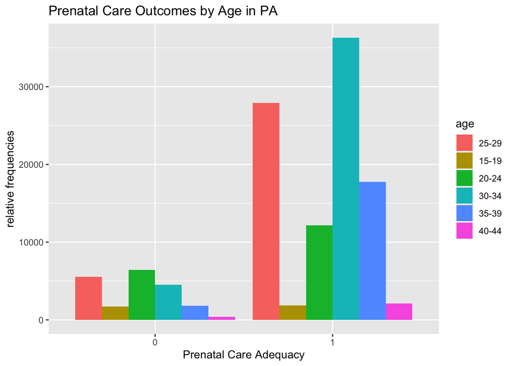

```r
#Age
clean_PA %>%
  ggplot(aes(x = prenatal, fill = age)) +
    geom_bar(position = "dodge") +
    ggtitle("Prenatal Care Outcomes by Age in PA") +
    xlab("Prenatal Care Adequacy") +
    ylab("relative frequencies")
```

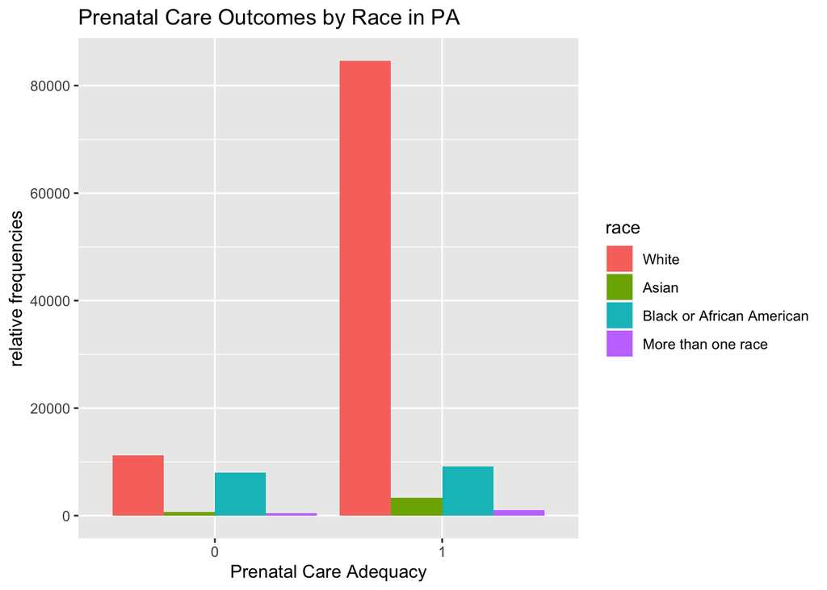

```r
#Race
clean_PA %>%
  ggplot(aes(x = prenatal, fill = race)) +
    geom_bar(position = "dodge") +
    ggtitle("Prenatal Care Outcomes by Race in PA") +
    xlab("Prenatal Care Adequacy") +
    ylab("relative frequencies")
```

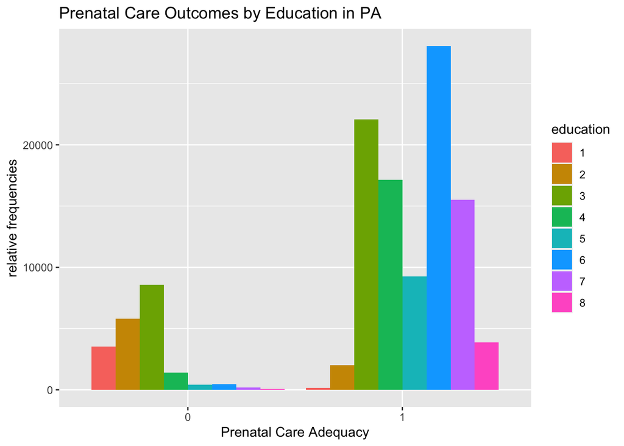

```r
# Education
clean_PA %>%
  ggplot(aes(x = prenatal, fill = education)) +
    geom_bar(position = "dodge") +
    ggtitle("Prenatal Care Outcomes by Education in PA") +
    xlab("Prenatal Care Adequacy") +
    ylab("relative frequencies")
```

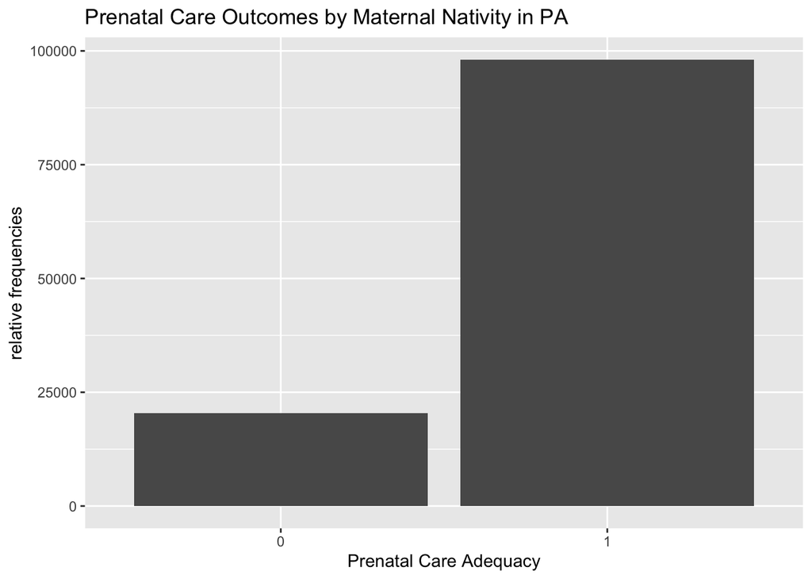

```r
#Nativity
ggplot(data=clean_PA, aes(x=prenatal)) +
    geom_bar() +
    ggtitle("Prenatal Care Outcomes by Maternal Nativity in PA") +
    xlab("Prenatal Care Adequacy") +
    ylab("relative frequencies")
```

# Visualization Philly: Analysis of Bivariate relationships for each select predictor with adequate prenatal care outcomes

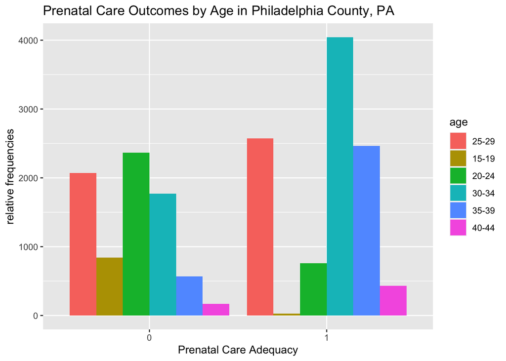

```r
#Age
clean_philly %>%
  ggplot(aes(x = prenatal, fill = age)) +
    geom_bar(position = "dodge") +
    ggtitle("Prenatal Care Outcomes by Age in Philadelphia County, PA") +
    xlab("Prenatal Care Adequacy") +
    ylab("relative frequencies")
```

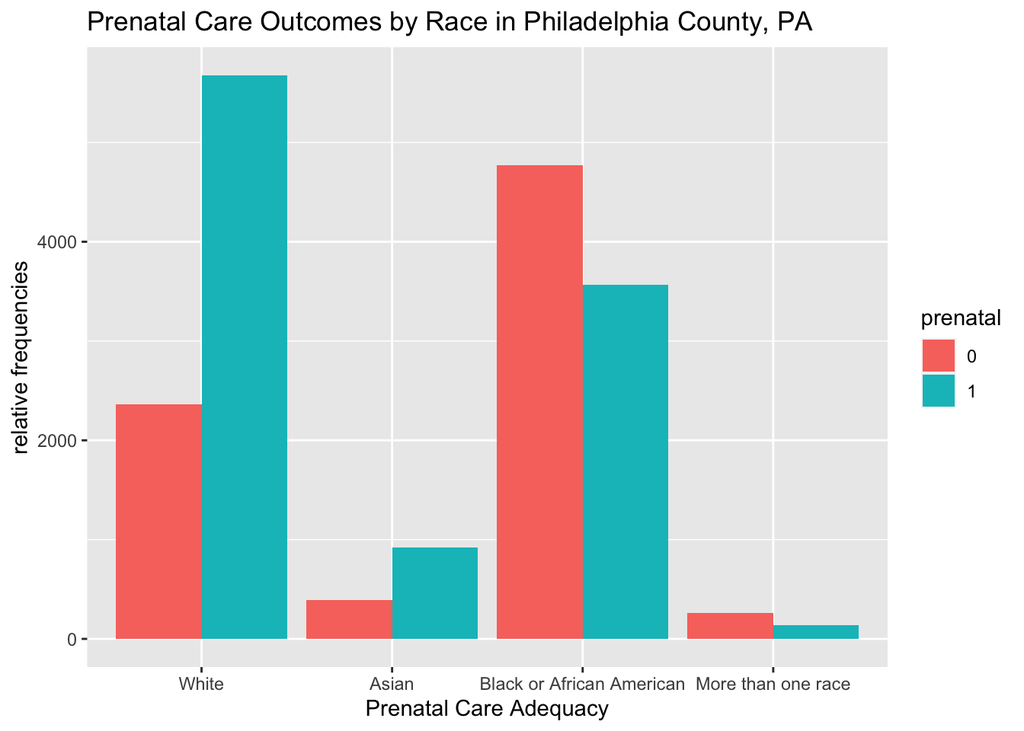

```r
#Race
clean_philly %>%
  ggplot(aes(x = race, fill = prenatal)) +
    geom_bar(position = "dodge") +
    ggtitle("Prenatal Care Outcomes by Race in Philadelphia County, PA") +
    xlab("Prenatal Care Adequacy") +
    ylab("relative frequencies")
```

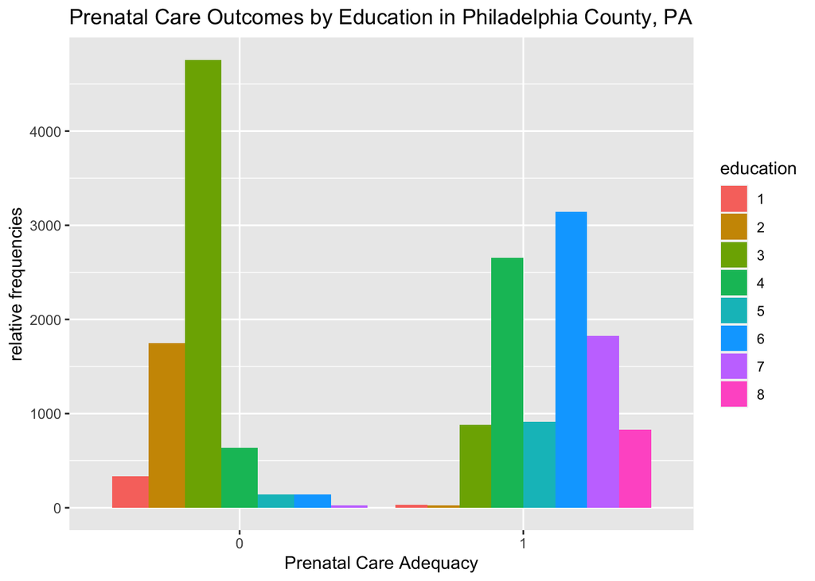

```r
# Education
clean_philly %>%
  ggplot(aes(x = prenatal, fill = education)) +
    geom_bar(position = "dodge") +
    ggtitle("Prenatal Care Outcomes by Education in Philadelphia County, PA") +
    xlab("Prenatal Care Adequacy") +
    ylab("relative frequencies")
```

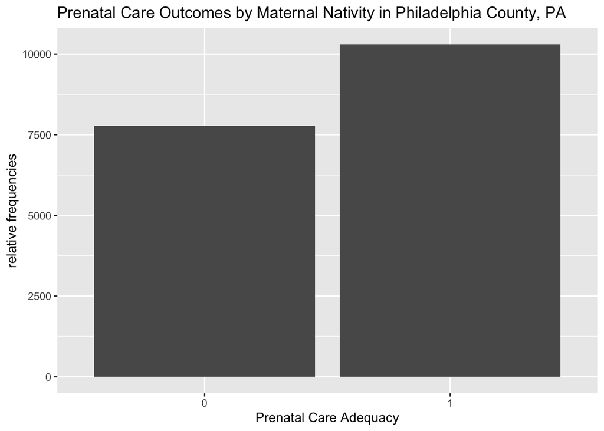

```r
#Nativity
ggplot(data=clean_philly, aes(x=prenatal)) +
    geom_bar() +
    ggtitle("Prenatal Care Outcomes by Maternal Nativity in Philadelphia County, PA") +
    xlab("Prenatal Care Adequacy") +
    ylab("relative frequencies")
```

### References

1. Committee to Study the Prevention of Low Birthweight. Ensuring Access to Prenatal Care. National Academies Press (US); 1985. Accessed November 6, 2022. https://www.ncbi.nlm.nih.gov/books/NBK214476/
2. Alexander GR, Korenbrot CC. The role of prenatal care in preventing low birth weight. Future Child. 1995;5(1):103-120.
3. Heaman MI, Sword W, Elliott L, et al. Barriers and facilitators related to use of prenatal care by inner-city women: perceptions of health care providers. BMC Pregnancy and Childbirth. 2015;15(1):2. doi:10.1186/s12884-015-0431-5
4. Peahl AF, Gourevitch RA, Luo EM, et al. Right-Sizing Prenatal Care to Meet Patients’ Needs and Improve Maternity Care Value. Obstetrics & Gynecology. 2020;135(5):1027-1037. doi:10.1097/AOG.0000000000003820
5. Pregnancy-Related Deaths: Data from Maternal Mortality Review Committees in 36 US States, 2017–2019 | CDC. Published September 17, 2022. Accessed September 20, 2022. https://www.cdc.gov/reproductivehealth/maternal-mortality/erase-mm/data-mmrc.html
6. Philadelphia Maternal Mortality Review Committee (MMRC). Improving Outcomes: Maternal Mortality in Philadelphia. Philadelphia Maternal Mortality Review Committee (MMRC); 2020. https://www.phila.gov/media/20210322093837/MMRReport2020-FINAL.pdf
7. Swartz JJ, Hainmueller J, Lawrence D, Rodriguez MI. Expanding Prenatal Care to Unauthorized Immigrant Women and the Effects on Infant Health. Obstetrics & Gynecology. 2017;130(5):938-945. doi:10.1097/AOG.0000000000002275
8. Munro K, Jarvis C, Munoz M, D’Souza V, Graves L. Undocumented Pregnant Women: What Does the Literature Tell Us? J Immigrant Minority Health. 2013;15(2):281-291. doi:10.1007/s10903-012-9587-5
9. Fabi R. Why Physicians Should Advocate for Undocumented Immigrants’ Unimpeded Access to Prenatal Care. AMA Journal of Ethics. 2019;21(1):93-99. doi:10.1001/amajethics.2019.93
10. Logistic Regression: Variables, RQs, and Assumptions.; 2021. Accessed December 1, 2022. https://www.youtube.com/watch?v=o7mWeZT4VH8